# EDA-iris

Priyasri Sankaran 5/24/2025

Dataset Source-Kaggle.com Dataset:Iris dataset is a very know dataset used is a good example of classification problem. There are 50 sample on each species. 150 samples. 3 different Species(Iris-setosa, Iris-versicolor, Iris-virginica). Features are SapalLengthCm, SapelWidthCm,PetalLengthCm, Species name. We will not be using the Id, we will drop them.

```python
import pandas as pd
import numpy as np
import matplotlib.pyplot as plt
import seaborn as sns
from sklearn.model_selection import train_test_split, GridSearchCV, cross_val_score
import scipy.stats as stats
import warnings
warnings.filterwarnings("ignore")
```

```python
print(pd.__version__, np.__version__)
```

```
2.2.3 1.26.4
```

Loading the Dataset

```python
df= pd.read_csv("iris.csv")
```

```python
#Display the first few rows
df.head()
```

|  | Id | SepalLengthCm | SepalWidthCm | PetalLengthCm | PetalWidthCm | Species |
| --- | --- | --- | --- | --- | --- | --- |
| 0 | 1 | 5.1 | 3.5 | 1.4 | 0.2 | Iris-setosa |
| 1 | 2 | 4.9 | 3.0 | 1.4 | 0.2 | Iris-setosa |
| 2 | 3 | 4.7 | 3.2 | 1.3 | 0.2 | Iris-setosa |
| 3 | 4 | 4.6 | 3.1 | 1.5 | 0.2 | Iris-setosa |
| 4 | 5 | 5.0 | 3.6 | 1.4 | 0.2 | Iris-setosa |

```python
print(df.columns)
```

```
Index(['Id', 'SepalLengthCm', 'SepalWidthCm', 'PetalLengthCm', 'PetalWidthCm',
       'Species'],
      dtype='object')
```

```python
#checking dataset shape(rows and columns)
df.shape
```

```
(150, 6)
```

```python
df.describe(include="all")
```

|  | Id | SepalLengthCm | SepalWidthCm | PetalLengthCm | PetalWidthCm | Species |
| --- | --- | --- | --- | --- | --- | --- |
| count | 150.000000 | 150.000000 | 150.000000 | 150.000000 | 150.000000 | 150 |
| unique | NaN | NaN | NaN | NaN | NaN | 3 |
| top | NaN | NaN | NaN | NaN | NaN | Iris-setosa |
| freq | NaN | NaN | NaN | NaN | NaN | 50 |
| mean | 75.500000 | 5.843333 | 3.054000 | 3.758667 | 1.198667 | NaN |
| std | 43.445368 | 0.828066 | 0.433594 | 1.764420 | 0.763161 | NaN |
| min | 1.000000 | 4.300000 | 2.000000 | 1.000000 | 0.100000 | NaN |
| 25% | 38.250000 | 5.100000 | 2.800000 | 1.600000 | 0.300000 | NaN |
| 50% | 75.500000 | 5.800000 | 3.000000 | 4.350000 | 1.300000 | NaN |
| 75% | 112.750000 | 6.400000 | 3.300000 | 5.100000 | 1.800000 | NaN |
| max | 150.000000 | 7.900000 | 4.400000 | 6.900000 | 2.500000 | NaN |

```python
df.info()
```

```
<class 'pandas.core.frame.DataFrame'>
RangeIndex: 150 entries, 0 to 149
Data columns (total 6 columns):
 #   Column         Non-Null Count  Dtype
---  ------         --------------  -----
 0   Id             150 non-null    int64
 1   SepalLengthCm  150 non-null    float64
 2   SepalWidthCm   150 non-null    float64
 3   PetalLengthCm  150 non-null    float64
 4   PetalWidthCm   150 non-null    float64
 5   Species        150 non-null    object
dtypes: float64(4), int64(1), object(1)
memory usage: 7.2+ KB
```

```python
df.isna().sum()
```

```
Id               0
SepalLengthCm    0
SepalWidthCm     0
PetalLengthCm    0
PetalWidthCm     0
Species          0
dtype: int64
```

No null values in the data.

```python
df.drop('Id', axis=1, inplace=True)
```

Dropped the Id column

```python
#checking after dropping the id column
df.info()
```

```
<class 'pandas.core.frame.DataFrame'>
RangeIndex: 150 entries, 0 to 149
Data columns (total 5 columns):
 #   Column         Non-Null Count  Dtype
---  ------         --------------  -----
 0   SepalLengthCm  150 non-null    float64
 1   SepalWidthCm   150 non-null    float64
 2   PetalLengthCm  150 non-null    float64
 3   PetalWidthCm   150 non-null    float64
 4   Species        150 non-null    object
dtypes: float64(4), object(1)
memory usage: 6.0+ KB
```

Bar Graph-count of each species

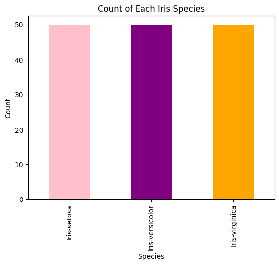

```python
df["Species"].value_counts().plot(kind="bar", color=["pink","purple","orange"])
plt.title("Count of Each Iris Species")
plt.xlabel("Species")
plt.ylabel("Count")
plt.show()
```

Pie Chart-Proportion of species

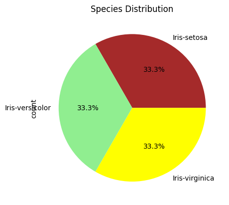

```python
df["Species"].value_counts().plot(kind="pie", autopct="%1.1f%%", colors=["brown", "lightgreen", "yellow"])
plt.title("Species Distribution")
plt.show()
```

The distribution of the data is even between the 3 species. We observe that from the above bar graph and the pie chart.

Histogram

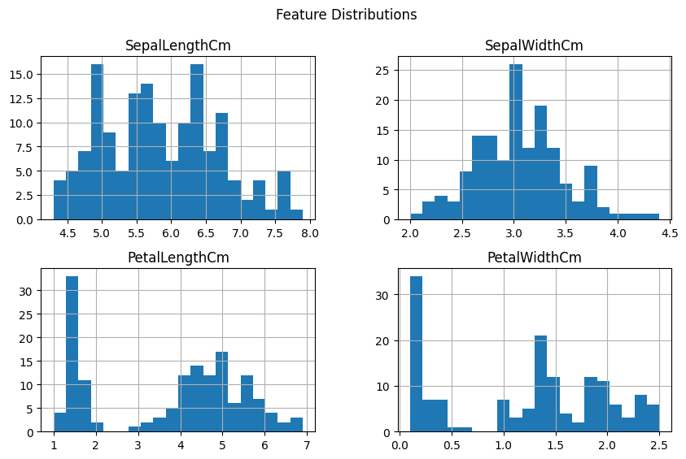

```python
df.hist(figsize=(10, 6), bins=20)
plt.suptitle("Feature Distributions")
plt.show()
```

We can clearly see the feature distribution of the data. SapelLengthCm and SapelWidthCm feature seems to be normally distributed in terms of their length and width in cm.

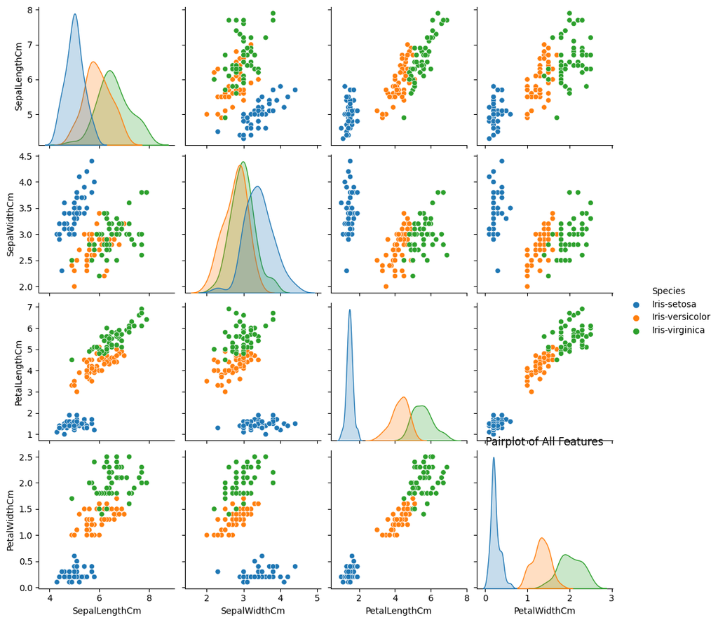

```python
# Pairplot (Comparison of all features)
sns.pairplot(df, hue="Species", diag_kind="kde")
plt.title("Pairplot of All Features")
plt.show()
```

Boxplots for detecting outliers

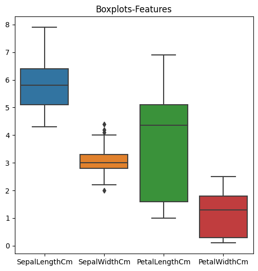

```python
plt.figure(figsize=(6,6))
sns.boxplot(data=df)
plt.title("Boxplots-Features")
plt.show()
```

Box Plot: We see the distribution of each feature on the box plot,they are not normally distributed. SepalLenthCm and SepalWidthCm or close to normal, we see that from the median. we see few outliers on SepalWidthCm. We will check on the Q-Q plot to comfirm this.

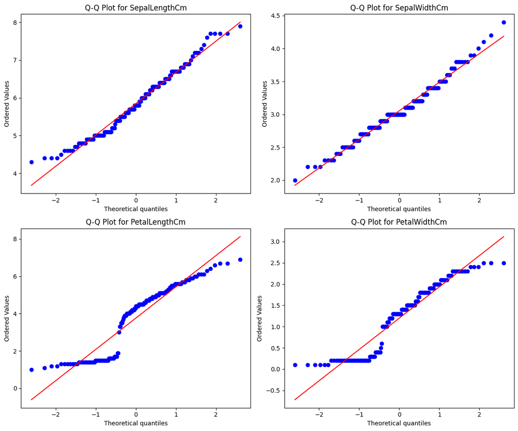

```python
features = ["SepalLengthCm", "SepalWidthCm", "PetalLengthCm", "PetalWidthCm"]

fig, axes = plt.subplots(2, 2, figsize=(12, 10))

for i, feature in enumerate(features):
    stats.probplot(df[feature], dist="norm", plot=axes[i//2, i%2])
    axes[i//2, i%2].set_title(f"Q-Q Plot for {feature}")

plt.tight_layout()
plt.show()
```

```python
The Q-Qplot confirms our observation, that the SepalLength and
SepalWidth are very close to normal distribution. The PetalLength and
PetalWidth are not normally distributed. we see few points near both the tail end of the data
few poits are off from the 45 degree line.
```

Scatter plot of petal length vs petal width

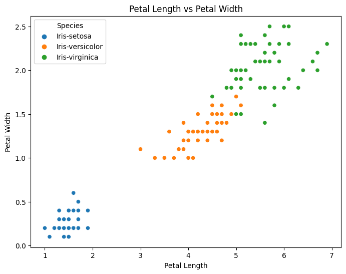

```python
# Scatter plot of petal length vs petal width
plt.figure(figsize=(8,6))
sns.scatterplot(x=df["PetalLengthCm"], y=df["PetalWidthCm"], hue=df["Species"])
plt.title("Petal Length vs Petal Width")
plt.xlabel("Petal Length")
plt.ylabel("Petal Width")
plt.show()
```

```python
from sklearn.preprocessing import LabelEncoder
#initialzing encoder
label_encoder= LabelEncoder()

#Encode the species column
df["Species"]= label_encoder.fit_transform(df["Species"])

#Checking the mapping
print(dict(zip(label_encoder.classes_, label_encoder.transform(label_encoder.classes_))))
print(df.head())
```

```
{'Iris-setosa': 0, 'Iris-versicolor': 1, 'Iris-virginica': 2}
   SepalLengthCm  SepalWidthCm  PetalLengthCm  PetalWidthCm  Species
0            5.1           3.5            1.4           0.2        0
1            4.9           3.0            1.4           0.2        0
2            4.7           3.2            1.3           0.2        0
3            4.6           3.1            1.5           0.2        0
4            5.0           3.6            1.4           0.2        0
```

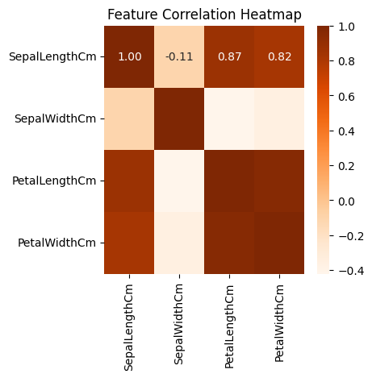

```python
import seaborn as sns
import matplotlib.pyplot as plt

# Ensure only numeric data is used
numeric_df = df.select_dtypes(include=["float64", "int64"])

# Compute correlation matrix
corr_matrix = numeric_df.corr()

# Generate heatmap
plt.figure(figsize=(4, 4))
sns.heatmap(corr_matrix, annot=True, cmap="Oranges", fmt=".2f")

plt.title("Feature Correlation Heatmap")
plt.show()
```

```python
Sepallength and  PetalLength has a correlation of .87, sepallength increases
PetalLength tends to increase.

SepalLength and petalWidth has next high correlation of 0.82. Longer sepals
are associated with petals.

SepalLegth and SepalWidth has a correlation of -0.11, which is a slight negative
correlation. Wider sepals might correspond to shorter lengths in some cases.
```